# lab3

Importing all the required libraries: --> What problem to be solved?

1. Problem: Impact on Blood Pressure based on BMI
2. We can easily predict if the change in BMI can impact the blood pressure of the person.
3. This can be efficiently used in healthcare to determine pre symptoms of a major disease.

```python
import numpy as np
from sklearn.model_selection import train_test_split
from sklearn.metrics import mean_squared_error
from sklearn.linear_model import LinearRegression
from sklearn import metrics
import matplotlib.pyplot as plt
from sklearn import datasets
import pandas as pd
```

--> What is the data? Loading the Diabetes Dataset from scikit learn.

```python
diabetes_X, diabetes_y = datasets.load_diabetes(return_X_y=True)
```

--> How to explore data? Exploring the data and converting it into its dataframes so that we can work on the feature.

```python
diabetes=datasets.load_diabetes()

df= pd.DataFrame(data=diabetes.data,columns=diabetes.feature_names)
```

--> What are the dependent and independent features?

1. BMI is the independent feature
2. BP is the dependent feature

Creating its respective data frames to identify X as independent variable and y as dependent variable.

```python
x = np.array(df["bmi"]).reshape((-1, 1))
y = np.array(df["bp"])
```

--> What model ?

Linear Regression Model problem as it specifies the relation between dependent and independent variables. We are testing 25% of the data.

```python
X_train, X_test, y_train, y_test = train_test_split(x, y, test_size=0.25, random_state=0)
```

```python
model = LinearRegression()
model.fit(X_train, y_train)
```

```
LinearRegression()
```

Based on our prediction , the slope and intercept of the model defines that If BMI is increasing there is a slight possibility that the BP of the person could increase.

```python
y_pred = model.predict(X_test)
print('Slope:', model.coef_)
print('Intercept: ', model.intercept_)
mse = mean_squared_error(X_test, y_test)
print("Mean squared Error: ", mse)
```

```
Slope: [0.42117299]
Intercept:  -0.0004081388008930289
Mean squared Error:  0.003101627856270364
```

Plotting scattered graph to show tested values and predicted value.

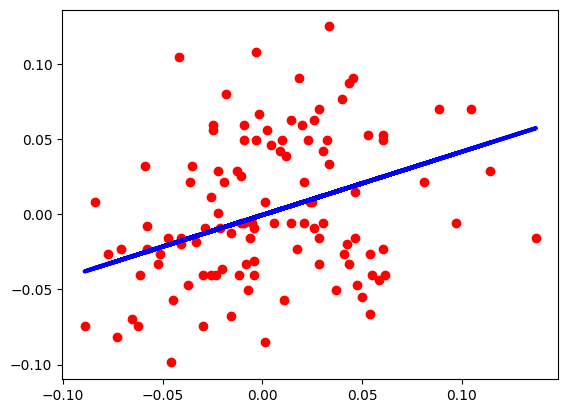

```python
plt.scatter(X_test, y_test,  color='red')
plt.plot(X_test, y_pred, color='blue', linewidth=3)

plt.show()
```